# Intro

This notebook takes us through the entire data science pipeline of importing and cleaning data, training and selecting models, and finally forming predictions on the unlabeled test data. These data represent the demographics and response/payment of a mail acquisition campain. The goal of this case is to use the 50k rows of labeled data to create a model that will give predictions to maximize revenue from 5,000 mailings sent to the top-scored recipients selected of the 50k-row unlabeled data set.

## Step 0: import libraries

```python
import pandas as pd
import numpy as np
import seaborn as sns
import matplotlib.pyplot as plt
from sklearn.ensemble import RandomForestClassifier, ExtraTreesClassifier, GradientBoostingClassifier
from sklearn.linear_model import LogisticRegression, LinearRegression
from sklearn.neighbors import KNeighborsClassifier
from sklearn.metrics import accuracy_score, confusion_matrix, roc_curve
from sklearn.pipeline import Pipeline
from sklearn.feature_selection import SelectFromModel
import time, math, pickle, itertools
import xgboost as xgb
%matplotlib inline
```

## Step 1: import and clean the data

In this step, we import the data from a CSV file, fill in missing values with the column mean values, create an id-to-payment dictionary, and encode all categorical data both in one-hot encoding and ordinal integers.

```python
# set random number generator seed
_seed = 0
df = pd.read_csv('../data/training_data.csv')

# shuffle rows, index on W_ID, and remove trailing whitespace from column names
df = df.sample(frac=1, random_state=_seed).reset_index(drop=True)
df = df.set_index(df.W_ID)
df.columns = [c.strip() for c in df.columns.values]

# drop the column will all missing values
df = df.drop('colname',1)

# fill in missing values, replace missing continuous values with the average of the rows
df = df.replace(-1, np.nan)
cont_feats = df.select_dtypes(include=[np.number]).columns
df.loc[:,cont_feats] = df.loc[:,cont_feats].fillna(df.loc[:,cont_feats].mean())

# make a categorical variable of response amount
# df['payment_categorical'] = df['Payment'].astype('category')

# # properly process categorical variables
# for col in df.columns:
#     if df[col].dtype == 'object':
#         df.loc[:,col] = df.loc[:,col].astype('category')

# encode categories as dummy (ordinal and one-hot) variables and create scoring lookup dictionary
lookup_df = df[['W_ID', 'Payment']]
lookup_dict = df['Payment'].to_dict()
onehot_df = pd.get_dummies(df)
for feature in df.columns: # Loop through all columns in the dataframe
    if df[feature].dtype.name == 'object': # Only apply for columns with categorical strings
        df[feature] = pd.Categorical(df[feature]).codes # Replace strings with an integer
```

## Step 1.5: define some useful functions

We need to create some additional functionality that isn't in the libraries we will use in order to split the dataset without losing the W_ids of our rows as well as to evaluate our performance.

```python
colvec_to_array = lambda colvec: np.asarray(colvec).ravel()
def split_dset(df, features, target, rng_seed, testset_size = 0.25, cat_to_dummies=False, verbose=False):
    '''
    Splits the dataframe into train/test subsets, then
    extracts numpy matrices of features and numpy arrays
    of W_ids and target labels
    '''
    # first, convert categorical to dummy variables
    thresh = math.ceil(testset_size * df.shape[0])
    test = df.iloc[:thresh, :]
    train = df.iloc[thresh:, :]
    if verbose:
        print('TRAIN Average response per mailing: $' + str(train.Payment.mean()))
        print('TEST Average response per mailing: $' + str(test.Payment.mean()))
    train_ids = colvec_to_array(train['W_ID'].as_matrix())
    test_ids = colvec_to_array(test['W_ID'].as_matrix())
    x_train = pd.get_dummies(train[features]).as_matrix() if cat_to_dummies else train[features].as_matrix()
    x_test = pd.get_dummies(test[features]).as_matrix() if cat_to_dummies else test[features].as_matrix()
    y_train = colvec_to_array(train[[target]].as_matrix())
    y_test = colvec_to_array(test[[target]].as_matrix())
    return (train_ids, test_ids, x_train, x_test, y_train, y_test)
def split_dset_with_valid(df, features, target, rng_seed, valset_size = 0.25,
                          testset_size = 0.25, cat_to_dummies=False,
                          verbose=False,
                          #even_label_dist=False
                         ):
    '''
    Splits the dataframe into train/test subsets, then
    extracts numpy matrices of features and numpy arrays
    of W_ids and target labels
    '''
    # first, convert categorical to dummy variables
    thresh1 = math.ceil(valset_size * df.shape[0])
    thresh2 = thresh1 + math.ceil(testset_size * df.shape[0])
    test = df.iloc[:thresh1, :]
    valid = df.iloc[thresh1:thresh2, :]
    train = df.iloc[thresh2:, :]
    if verbose:
        print('TRAIN Average response per mailing: $' + str(train.Payment.mean()))
        print('VALID Average response per mailing: $' + str(valid.Payment.mean()))
        print('TEST Average response per mailing: $' + str(test.Payment.mean()))
    train_ids = colvec_to_array(train['W_ID'].as_matrix())
    valid_ids = colvec_to_array(valid['W_ID'].as_matrix())
    test_ids = colvec_to_array(test['W_ID'].as_matrix())
    x_train = pd.get_dummies(train[features]).as_matrix() if cat_to_dummies else train[features].as_matrix()
    x_valid = pd.get_dummies(valid[features]).as_matrix() if cat_to_dummies else valid[features].as_matrix()
    x_test = pd.get_dummies(test[features]).as_matrix() if cat_to_dummies else test[features].as_matrix()
    y_train = colvec_to_array(train[[target]].as_matrix())
    y_valid = colvec_to_array(valid[[target]].as_matrix())
    y_test = colvec_to_array(test[[target]].as_matrix())
    return (train_ids, valid_ids, test_ids, x_train, x_valid, x_test, y_train, y_valid, y_test)
def per_mailing_revenue(output, mailing_proportion = .1):
    '''
    Calculates the average mailing response for the top proportion*100% of
    predicted responders
    '''
    mailing_size = math.ceil(len(output)*mailing_proportion)
    output = output.sort_values(by='probability', ascending = False)
    total_revenue = 0
    for wid in output.iloc[:mailing_size,0]:
        total_revenue = total_revenue + lookup_dict[wid]
    return total_revenue/mailing_size
def get_response_rate(output, mailing_proportion = .1):
    '''
    Calculates the average mailing response rate for the top
    proportion*100% of predicted responders
    '''
    mailing_size = math.ceil(len(output)*mailing_proportion)
    output = output.sort_values(by='probability', ascending = False)
    total_responses = 0
    for wid in output.iloc[:mailing_size,0]:
        if lookup_dict[wid] > 0:
            total_responses += 1
    return total_responses/mailing_size
def plot_confusion_matrix(cm, classes = ['No Response', 'Response'],
                          normalize=False,
                          title='Confusion matrix',
                          cmap=plt.cm.Blues):
    """
    This function prints and plots the confusion matrix.
    Normalization can be applied by setting `normalize=True`.
    (code adapted from example in sklearn tutorial)
    """
    if normalize:
        cm = cm.astype('float') / cm.sum(axis=1)[:, np.newaxis]

    plt.imshow(cm, interpolation='nearest', cmap=cmap)
    plt.title(title)
    plt.colorbar()
    tick_marks = np.arange(len(classes))
    plt.xticks(tick_marks, classes, rotation=45)
    plt.yticks(tick_marks, classes)

    thresh = cm.min() + (cm.max() - cm.min()) / 2.
    for i, j in itertools.product(range(cm.shape[0]), range(cm.shape[1])):
        plt.text(j, i, cm[i, j],
                 horizontalalignment="center",
                 color="white" if cm[i, j] > thresh else "black")

    plt.tight_layout()
    plt.ylabel('True label')
    plt.xlabel('Predicted label')
    plt.show()
def plot_ROC(data, lw=1):
    '''
    Takes an iterable of tuples containing (model_title, true_labels, predictions)
    '''
    pal = sns.color_palette("hls", len(data))
    plt.figure()
    for color_id, (title, true_labels, predictions) in enumerate(data):
        fpr, tpr, thresholds = roc_curve(true_labels, predictions)
        plt.plot(fpr, tpr,
                 label='{} ROC curve'
                       ''.format(title),
                 color=pal[color_id], linewidth=lw)
    plt.plot([0, 1], [0, 1], 'k--', lw=lw)
    plt.xlim([0.0, 1.0])
    plt.ylim([0.0, 1.05])
    plt.xlabel('False Positive Rate')
    plt.ylabel('True Positive Rate')
    plt.title('Receiver operating characteristic')
    plt.legend(loc="lower right")
    plt.show()
```

## Step 2: get a baseline

Here we seek to establish and understand the "baseline" model that we are improving upon.

```
Number of responders (out of 50k): 5000
Average response per mailing: $12.798
```

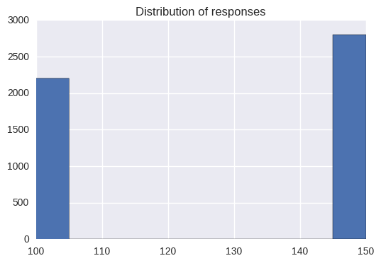

```python
# just taking a quick looks at the distribution of giving
print('Number of responders (out of 50k):',sum(df.Responder_Flg))
print('Average response per mailing: $' + str(df.Payment.mean()))

plt.figure()
plt.title('Distribution of responses')
plt.hist(df.Payment[df.Payment != 0])
plt.show()
```